# CNN Project Part -1

## (3.4) Create the Training and validation data set using ImageDataGenerator and with scaling only

### (3.4.1) Creating Train and Validation data using the ImageDataGenerator

```python
data_gen = tf.keras.preprocessing.image.ImageDataGenerator(rescale=1./255,
                                                          #  rotation_range=20,
                                                          #   width_shift_range=0.2,
                                                          #   height_shift_range=0.2,
                                                          #   horizontal_flip=True,
                                                          #   vertical_flip=True,
                                                            validation_split=0.2
                                                        )
```

```python
train_gen = data_gen.flow_from_directory(base_path+train_path,
                                    target_size=(img_rsz_ht, img_rsz_wd),
                                    subset='training',
                                    class_mode='sparse',
                                    batch_size=batch_size,
                                    shuffle=True,
                                    seed=random_state
                                    )
```

```
Found 3816 images belonging to 12 classes.
```

```python
val_gen = data_gen.flow_from_directory(base_path+train_path,
                                       target_size=(img_rsz_ht, img_rsz_wd),
                                        subset='validation',
                                        class_mode='sparse',
                                        batch_size=batch_size,
                                        shuffle=True,
                                        seed=random_state
                                      )
```

```
Found 951 images belonging to 12 classes.
```

#### Holding the number of output classes in a variable

```python
op_classes = train_gen.num_classes
op_classes
```

```
12
```

### (3.4.2) Creating the test dataset using ImageDataGenerator

```python
test_img_df = pd.read_csv(base_path+test_path+'/Test Data Annotation.csv')
# test_img_df['species_index'] = test_img_df['species'].map(train_gen.class_indices)
display(test_img_df.head())
display(Markdown(f"#### There are a total of {len(test_img_df)} test images"))
```

|  | file | species |
| --- | --- | --- |
| 0 | 0021e90e4.png | Sugar beet |
| 1 | 003d61042.png | Sugar beet |
| 2 | 007b3da8b.png | Sugar beet |
| 3 | 0086a6340.png | Sugar beet |
| 4 | 00c47e980.png | Sugar beet |

There are a total of 794 test images

```python
test_data = tf.keras.preprocessing.image.ImageDataGenerator(rescale=1./255)

test_gen = test_data.flow_from_dataframe(test_img_df,
                                         directory=base_path+test_path,
                                         target_size=(img_rsz_ht, img_rsz_wd),
                                         class_mode = 'sparse',
                                         x_col = 'file',
                                         y_col = 'species')
```

```
Found 794 validated image filenames belonging to 1 classes.
```

```python
def get_train_test_split(dgen):
  dgen.reset()
  x_array, y_array = next(dgen)
  for i in tqdm(range(int(len(dgen)-1))): #1st batch is alread fetched before the for loop
    img, label = next(dgen)
    x_array = np.append(x_array, img, axis=0 )
    y_array = np.append(y_array, label, axis=0)
  return x_array, y_array
```

```python
X_test, y_test = get_train_test_split(test_gen)
y_test = pd.Series(y_test).map({v:k for k,v in test_gen.class_indices.items()})
y_test = y_test.map(train_gen.class_indices).values
display(Markdown(f"#### Shape of Test Image set is {X_test.shape} and their labels as {y_test.shape}"))
```

Shape of Test Image set is (794, 224, 224, 3) and their labels as (794,)

## (3.5) Reading the image to be predicted and processing it

Original Image to be predicted (578, 578, 3)

Resized Image to be predicted (224, 224, 3)

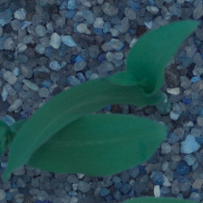

```python
img_pred = cv2.imread('/content/drive/MyDrive/Colab Notebooks/DataFile/Part-1 - Plant Seedling Classification Data/Seedling - Prediction/Predict.png')
display(Markdown(f"### <u>Original Image to be predicted {img_pred.shape}"))
cv2_imshow(img_pred)
img_predict = cv2.cvtColor(img_pred, cv2.COLOR_BGR2RGB)
img_predict = cv2.resize(img_predict, (img_rsz_ht, img_rsz_wd))
display(Markdown(f"### <u>Resized Image to be predicted {img_predict.shape}"))
cv2_imshow(img_predict)
img_predict = np.expand_dims(img_predict, axis=0)
```

#### Observations:

1. The image to be predicted seems like `Maize`. Let's see what each architecture and algorithms predict

# (4) Modelling

## (4.1) Creating helper classes to `Live Plot` and create `CNNs` and `ANNs`

```python
class LivePlot(tf.keras.callbacks.Callback):

    def __init__(self,refresh_rate=5,train_loss=None,train_metric=None):
        self.validation_prefix = "val_"
        self.refresh_rate = refresh_rate
        self.train_loss = train_loss
        self.val_loss = self.validation_prefix + train_loss
        self.train_metric = train_metric
        self.val_metric = self.validation_prefix + train_metric

    # This function is called when the training begins
    def on_train_begin(self, logs={}):
        # Initialize the lists for holding the logs, losses and metrics
        self.train_losses = []
        self.train_metrics = []
        self.val_losses = []
        self.val_metrics = []

        self.logs = []

    # This function is called at the end of each epoch
    def on_epoch_end(self, epoch, logs={}):
        """
        Calculates and plots loss and metrics
        """
        # Extract from the log
        log_train_loss = logs.get(self.train_loss)
        log_train_metric = logs.get(self.train_metric)
        log_val_loss = logs.get(self.val_loss)
        log_val_metric = logs.get(self.val_metric)

        # Append the logs, losses and accuracies to the lists
        self.logs.append(logs)
        self.train_losses.append(log_train_loss)
        self.train_metrics.append(log_train_metric)
        self.val_losses.append(log_val_loss)
        self.val_metrics.append(log_val_metric)

        # Plots every nth epoch
        if epoch > 0 and epoch%self.refresh_rate == 0:
            fig, ax = plt.subplots(1,2,figsize=(20,6))
            clear_output(wait=True)
            N = np.arange(0, len(self.train_losses))

            sns.lineplot(x=N,y=self.train_losses,ax=ax[0],legend='brief',label=self.train_loss)
            sns.lineplot(x=N, y = self.val_losses,ax=ax[0],legend='brief',label=self.val_loss)
            ax[0].set_title('Loss over Epoch',{'fontsize':20})
            # ax[0].set_title(f'Loss over Epoch {epoch} - {log_train_loss:.3}/{log_val_loss:.3} - (T/V)\n',{'fontsize':20})
            ax[0].set_xlabel('Epochs')
            ax[0].set_ylabel(self.train_loss)

            sns.lineplot(x=N,y=self.train_metrics,ax=ax[1],legend='brief',label=self.train_metric)
            sns.lineplot(x=N,y=self.val_metrics,ax=ax[1],legend='brief',label=self.val_metric)
            ax[1].set_title('Performance over Epoch ',{'fontsize':20})
            # ax[1].set_title(f'Performance over Epoch {epoch} - {log_train_metric:.3}/{log_val_metric:.3} - (T/V) \n',{'fontsize':20})
            ax[1].set_xlabel('Epochs')
            ax[1].set_ylabel(self.train_metric)
            plt.show()
```

```python
def createCNNModel(img_shape,num_ops,loss='sparse_categorical_crossentropy',metrics=['acc'] ):

  model = tf.keras.models.Sequential()
  model.add(InputLayer(input_shape=(img_shape[0],img_shape[1],img_shape[2])))

  model.add(Conv2D(64, kernel_size=(3,3), activation='relu'))
  model.add(MaxPool2D(pool_size = (2,2)))
  model.add(BatchNormalization())

  model.add(Conv2D(64, kernel_size=(3,3), strides = (1,1), activation='relu'))
  model.add(MaxPool2D(pool_size = (2,2)))
  model.add(BatchNormalization())

  model.add(Conv2D(128, kernel_size=(3,3), strides = (1,1), activation='relu'))
  model.add(MaxPool2D(pool_size = (2,2)))
  model.add(BatchNormalization())

  model.add(Conv2D(128, kernel_size=(3,3), strides = (1,1), activation='relu'))
  model.add(MaxPool2D(pool_size = (2,2)))
  model.add(GlobalMaxPool2D())

  model.add(Flatten())
  model.add(BatchNormalization())
  model.add(Dense(1024, activation='relu'))
  model.add(Dropout(0.2))

  model.add(BatchNormalization())
  model.add(Dense(512, activation='relu'))
  model.add(Dropout(0.2))

  model.add(BatchNormalization())
  model.add(Dense(256, activation='relu'))
  model.add(Dropout(0.2))

  model.add(BatchNormalization())
  model.add(Dense(num_ops, activation='softmax'))

  model.compile(optimizer='adam', loss=loss, metrics=metrics)
  model.summary()
  return model
```

```python
def createANNModel(img_shape,num_ops,loss='sparse_categorical_crossentropy',metrics=['acc'] ):

  model = tf.keras.models.Sequential()
  model.add(InputLayer(input_shape=(img_shape[0],img_shape[1],img_shape[2])))

  model.add(Flatten())
  model.add(BatchNormalization())
  model.add(Dense(1024, activation='relu'))
  model.add(Dropout(0.2))

  model.add(BatchNormalization())
  model.add(Dense(512, activation='relu'))
  model.add(Dropout(0.2))

  model.add(BatchNormalization())
  model.add(Dense(256, activation='relu'))
  model.add(Dropout(0.2))

  model.add(BatchNormalization())
  model.add(Dense(num_ops, activation='softmax')) # = 12 predicted classes

  model.compile(optimizer='adam', loss=loss, metrics=metrics)
  model.summary()
  return model
```

## (4.2) Creating Callback Functions and score board to hold performance and loss metrics for each method of recognition

```python
liveplot = LivePlot(1,train_loss='loss',train_metric='acc')
early_stop = EarlyStopping(monitor = 'val_loss', patience = epochs//10, mode = 'min')
# reduce_lr = ReduceLROnPlateau(monitor = 'loss', factor = 0.2, patience = epochs//10, min_lr = 1e-6, verbose = 1, mode = 'min')
```

```python
score_board = pd.DataFrame(columns=['Model','Best_Train_Loss','Best_Train_Accuracy','Best_Val_Loss','Best_Val_Accuracy','Test_Loss','Test_Accuracy','Predicted_Label','Notes'])
score_board
```

|  | Model | Best_Train_Loss | Best_Train_Accuracy | Best_Val_Loss | Best_Val_Accuracy | Test_Loss | Test_Accuracy | Predicted_Label | Notes |
| --- | --- | --- | --- | --- | --- | --- | --- | --- | --- |